# Overview of tv data from the certain wolf database

Andres Karjus

16/06/2021

# 1 General overview

Node size is number of rows in a given table, edge size is number of overlapping PROG_ID values between 2 tables.

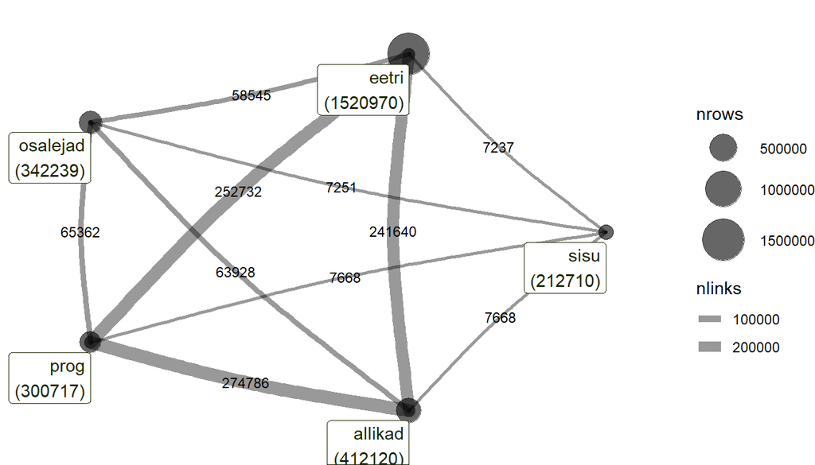

# 2 Osalejad / the people and roles dataset (n=342239)

Number of issues:

- unicode letters (umlauts etc) are broken at the encoding level; I suspect this has gone through multiple broken re-encodings, as the “entities” they end up in are not typical UTF->ANSI errors, and are mixed with unicode-looking control chars
- Some columns contain multiple entires in one cell, like REF_OSALUST, which lists all role types for a given actor or participant in a show (could be split apart if delimiting is systematic), or OSALEJA (participant) which can have longer descriptions like *videoinsertide autorid Olavi Pihlam?„gi ja Marek Inno* or *Interpreet Anu Kaal ja Hendrik Krumm*. The longest such description is this: *Läti NSV Kutsehariduse Kultuurimaja akad. Koor “Daile”. Dir. Gido Kokor. Orelil Peteris Sipolnieks*. In principle records like this could be broken apart into multiple entries by using Named Entity Recognition, detecting names, and given them separate entries, keeping the rest of the metadata the same.
- OSALEJA field sometimes has last name only, sometimes it’s band names, sometimes first name is abbreviated to initials only.
- There are empty cells - some make sense, if a show is not in a series then series is empty; but the role type is also sometimes empty.
- 10475 missing IDs in INDEKS (cooccurs with NA in SERIES_ID not always; but PROG_ID always present)
- sometimes the role and role type are in the PEALKIRI (title) field (e.g. “Saatejuht Margus Saar”)
- sometimes (14726 times) OSALEJA is just “ETV”.

Also it’s pretty sparse - the median number of participants per PROG_ID is 3, a lot have just one person attached (it might be because there’s multiple people listed in this single entry - but looking at the 19341 single-person program participant entires, they’re not that long either, median 12 characters; you might think it’s because of the pre-2000 sparse data, but 17083 of the one-man-shows are post-2000). So detecting names might help and populate the dataset a bit, but not much. I don’t know much about tv production, but just median 3 people per tv show or episode or whatever doesn’t sound realistic. Either we have a partial dataset or the data is just really patchy. Looking at the roles list above, sometimes tens of specific and/or minor roles are mentioned - while it seems for others, only the most important couple of people are mentioned. And sometimes it’s multiple entires but it’s the same person mentioned in multiple roles.

|  | INDEKS | PROG_ID | SERIES_ID | SAATE_PEALKIRI | SARJA_PEALKIRI | ROLL | REF_OSALUST.œ.œP | OSALEJA |
| --- | --- | --- | --- | --- | --- | --- | --- | --- |
| 1 | 2013-001585-0033 | 10073949102 | 10071834410 |  | Pehmed ja karvased | Hunt,Rein,Konstantin | N?¤itleja | T?µnu Oja |
| 6 | 2013-001585-0033 | 10073949102 | 10071834410 |  | Pehmed ja karvased | Evelin,J?¤nes,Laine | N?¤itleja | Piret Kalda |
| 2444 | 2006-002086-0009 | 10029559305 | 10028011397 | Draamateater | Teatriaasta 12 kuud | Ver& |  |  |
| 1000 | 2012-000001-0540 | 10069359987 | 10069343588 |  | ?•nne 13 | Evelin Sumberg | N?¤itleja | Marika Korolev |
| 340000 | 2017-024664-0012 | 10145579685 | 10141458747 |  | Rambipalavik |  | T?µlge Sisu | Piret Raudsepp |
| 35805 | 2004-017579-0001 | 10008254315 | NA | Iceland - Happiest Nation |  |  | Levitaja | German United Distr. |
| 58077 |  | 10010500080 | NA | P?¤ikesej?¤nku |  |  | Muusika | S.TadÅ¾imuratov |

The broken letters issue is mostly fixable with simple pattern matching:

|  | INDEKS | PROG_ID | SERIES_ID | SAATE_PEALKIRI | SARJA_PEALKIRI | ROLL | REF_OSALUST | OSALEJA |
| --- | --- | --- | --- | --- | --- | --- | --- | --- |
| 1 | 2013-001585-0033 | 10073949102 | 10071834410 |  | Pehmed ja karvased | Hunt,Rein,Konstantin | Näitleja | Tõnu Oja |
| 6 | 2013-001585-0033 | 10073949102 | 10071834410 |  | Pehmed ja karvased | Evelin,Jänes,Laine | Näitleja | Piret Kalda |
| 2444 | 2006-002086-0009 | 10029559305 | 10028011397 | Draamateater | Teatriaasta 12 kuud | Ver& |  |  |
| 1000 | 2012-000001-0540 | 10069359987 | 10069343588 |  | Õnne 13 | Evelin Sumberg | Näitleja | Marika Korolev |
| 340000 | 2017-024664-0012 | 10145579685 | 10141458747 |  | Rambipalavik |  | Tõlge Sisu | Piret Raudsepp |
| 35805 | 2004-017579-0001 | 10008254315 | NA | Iceland - Happiest Nation |  |  | Levitaja | German United Distr. |
| 58077 |  | 10010500080 | NA | Päikesejänku |  |  | Muusika | S.Tadžimuratov |

## 2.1 Values in the variables:

|  | n_unique_values | n_empty |
| --- | --- | --- |
| INDEKS | 60717 | 10475 |
| PROG_ID | 65362 | 0 |
| SERIES_ID | 4204 | 82305 |
| SAATE_PEALKIRI | 38689 | 117081 |
| SARJA_PEALKIRI | 3153 | 82372 |
| ROLL | 11376 | 305566 |
| REF_OSALUST | 203 | 75 |
| OSALEJA | 15962 | 75 |

|  | most_frequent |
| --- | --- |
| INDEKS | "" (10475), “1111-111111-1112” (127), “1968-082146-0001” (89), “2008-002451-0001” (66), “2009-000991-0032” (65), “2010-002388-0001” (65) |
| PROG_ID | “10146602376” (127), “10038626443” (89), “10039978617” (66), “10045475354” (65), “10050359457” (65), “10029559193” (64) |
| SERIES_ID | “10010572814” (6172), “10149973308” (2857), “10009674833” (2762), “10010576145” (1685), “10009755030” (1632), “10126750367” (1502) |
| SAATE_PEALKIRI | "" (117081), “Sport” (531), “Saatejuht Margus Saar” (252), “Finaal” (191), “2” (178), “Saatejuht Katrin Viirpalu” (168) |
| SARJA_PEALKIRI | "" (82372), “Õnne 13” (17060), “Pealtnägija” (5909), “Sport” (5219), “Pehmed ja karvased” (5055), “Osoon” (3931) |
| ROLL | "" (305566), “Tim” (647), “nukud” (389), “Mihkel” (377), “Timmu” (312), “Johannes” (272) |
| REF_OSALUST | “Operaator” (40313), “Näitleja” (35802), “Režissöör” (28139), “Levitaja” (21290), “Toimetaja” (17561), “Tõlge” (15615) |
| OSALEJA | “ETV” (14726), “Rein Lillmaa” (2028), “Margit Ossipova” (1914), “Taavi Tõnisson” (1901), “Toomas Karik” (1751), “Peeter Tungal” (1743) |

Most frequent categories in REF_OSALUST:

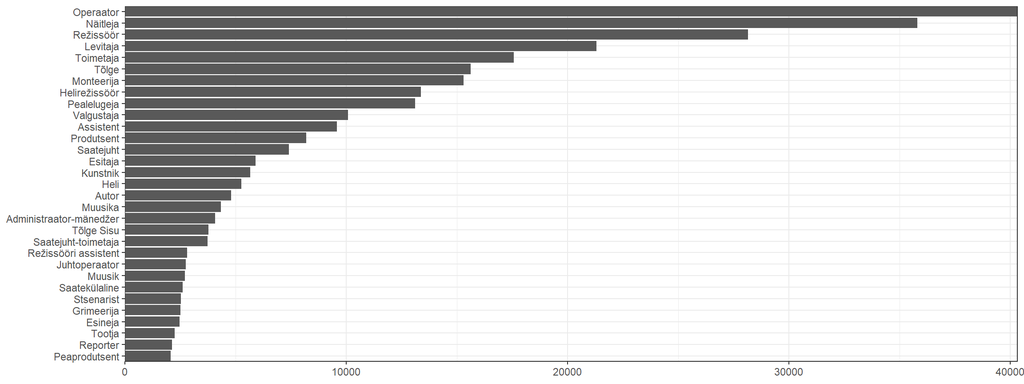

Less frequent categories (10…2000), in descending order:

```
## Helilooja, Arvutigraafik, Lavaseadja, Laulja, Osatäitja, Operaatori assistent, Tegevprodutsent, Autor-saatejuht, Autojuht, Subtitreerija, Kollektiiv, Dirigent, Amet määramata, Rekvisiitor, Videosalvestuse operaator, Insener, Valgus, LÜJ meeskond, Lavastaja, Kommentaator, Helitehnik, Filmiahiiv, M…
```

Least frequent categories (n<10), in descending order:

```
## Disainer, Õhtu juht, Muusikakonsultant, Võistkonna kapten, film, faseerija, Š ŠµŠ¶Šø??Šµ?€, Säilitaja, ŠŸ?€Š¾Š´???Šµ?€, Kirjakunstnik, Seade, Statist, Orig. Distributor, Publiku korraldaja, Š’ŠµŠ´?ƒ?‰ŠøŠ¹ ŠæŠµ?€ŠµŠ´Š°?‡Šø, Tantsujuht, kaasa teevad, Meedik, Tekstide mahakirjutaja, Vahekohtunik, Or…
```

## 2.2 Most frequent person-role co-occurrences:

| OSALEJA | REF_OSALUST | n |
| --- | --- | --- |
| ETV | Levitaja | 14546 |
| Rein Lillmaa | Operaator | 1670 |
| Ago Lõbu | Režissöör | 1585 |
| Peeter Tungal | Operaator | 1433 |
| Taavi Tõnisson | Pealelugeja | 1429 |
| Peep Laansalu | Operaator | 1262 |
| Andres Kull | Operaator | 1243 |
| Harriet Toompere | Pealelugeja | 1239 |
| Toomas Karik | Tõlge | 1215 |
| Raul Priks | Operaator | 1181 |
| Maiga Karlson | Režissöör | 1173 |
| Margit Ossipova | Assistent | 1171 |
| Avo Sillasoo | Operaator | 1139 |
| Jüri Hindremäe | Valgustaja | 1138 |
| Robert Vood | Operaator | 1126 |
| Anne Kiris | Tõlge | 1117 |
| Felix Grossmann | Operaator | 1109 |
| Tiina Vilu-Demjanov | Pealelugeja | 1106 |
| Meelis Kadastik | Operaator | 1104 |
| Enn Laidre | Helirežissöör | 1075 |
| Kalle Käärik | Monteerija | 1058 |
| Mart Kampus | Näitleja | 1050 |
| Renee Kelomees | Arvutigraafik | 1028 |
| Eva Kolli | Tõlge | 1005 |
| Maire Radsin | Režissöör | 945 |
| Tõnu Simm | Valgustaja | 910 |
| Eero Spriit | Peaprodutsent | 890 |
| Magnus Suitso | Operaator | 878 |
| Andres Jõenurm | Monteerija | 862 |
| Aivar Müür | Monteerija | 836 |

## 2.3 Gender distributions over time in the most common roles

- Uses a list of 5000 first names, focused on Estonian, Russian and Finnish, classfied as either “male” or “female”.
- This is matched against the first string in OSALEJA (delimited by space or hyphen - detection will rely on the first compnonent of multi-part names),
- preceded by a regex filter to get rid of most common cases of non-person-names (numbers, punctuation, >1 uppercase letters, mentions of film, tv, radio, music, band names, countries).
- Rows where the role type is one of “Filmiahiiv”, “Tootja”, “Levitaja”, “Õiguste omanik” are also ignored. OSALEJA is required to be between 2-50 characters, the inferred first name 2-11 (this seems to throw out a bunch of band and choir names, while keeping longer names like Christopher).

This filtering leaves 10,408 cases out of the original 342,239. The previously top frequent “operaator” category is reduced from 40k to 1231 (i.e. the names there are either initials, list multiple people, or no people at all), “näitleja” 36k->2038. Of those, the vast majority of names can be gendered simply by matching against the list (only 24 cases, 13 unique strings, are ambigous). Otherwise, the gender classifier could also use a bit of machine learning (e.g. string distance with k nearest neighbours) to classify unmatched names, but no need here really. This approach is, still, approximate, as some names might not be gender-specific, and this simple binary approach may misgender some people, including those who identify as nonbinary or trans. It is assumed though that this error margin would be reasonably low. It is also not impossible that less important roles are referred to using just initials, which means they’d be filtered out here; if the “importance” correlates with gender in some time periods, then this might also bias the results.

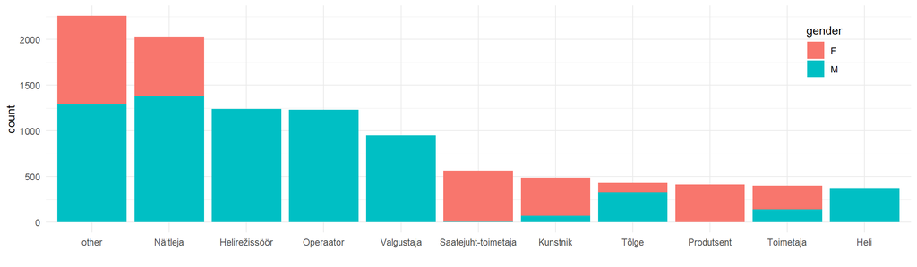

This graph above displays the most frequent role categories in the entire database (which has identifiable first names as the first element in the OSALEJA field), but it could also be done over time (for categories that have enough identifiable names…). The number of available datapoints could potentially be increased by making the name detection in the OSALEJA field more comprehensive (where multiple names are mentioned; still doesn’t help if just initials).

## 2.4 Participant networks

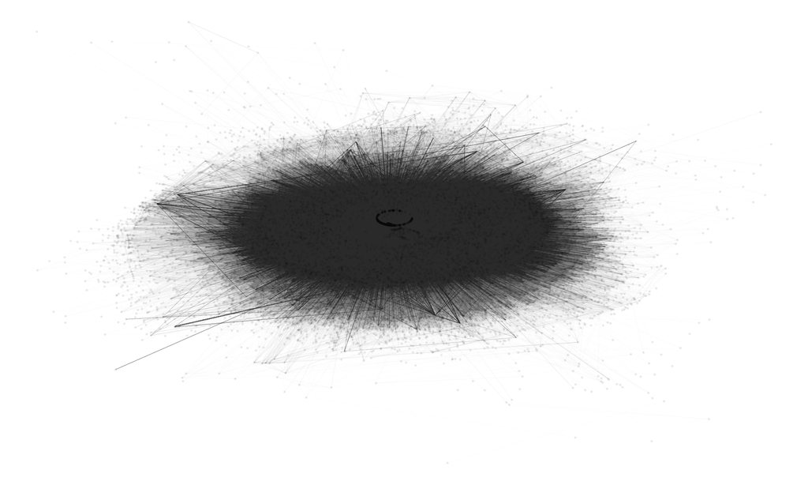

(but I guess the plot is not super informative)

# 3 EETRIAJAD / airing times dataset (n=1520970)

## 3.1 Values in the variables:

|  | n_unique_values | n_empty |
| --- | --- | --- |
| KUUPAEV | 14727 | 0 |
| ALGUS | 833216 | 13593 |
| KESTUS | 86611 | 13489 |
| KESTUS_MS | 86611 | 13489 |
| SAATE_PEALKIRI | 60865 | 221499 |
| SARJA_PEALKIRI | 36159 | 501924 |
| PROG_ID | 252732 | 0 |
| SERIES_ID | 53177 | 501924 |
| INDEKS | 251245 | 3535 |
| VERSION_ID | 196165 | 261400 |
| EPISOOD | 2431 | 504363 |
| ASLOT_ID | 1520970 | 0 |
| KANAL | 4 | 0 |
| REF_TOODANGU_LIIK | 10 | 2670 |
| REF_EETRI_TUUP | 14 | 28 |

|  | most_frequent |
| --- | --- |
| KANAL | “ETV1” (777411), “ETV2” (523538), “ETV+” (220019), “ETV KOOS” (2) |
| REF_TOODANGU_LIIK | “1.1 omasaade” (1265123), “2.1 hangitud saade” (200165), “1.2 koostöösaade” (21057), “1.3 tellitud saade” (17130), “1.1.1 omasaade litsentsiga” (7205), “2.2 litsentseeritud koostöö (spordi oiguste ost… |
| REF_EETRI_TUUP | “promo” (531360), “ident” (460972), “saade” (452675), “kultuuriteated” (25778), “online” (25083), “filler” (21821) |

## 3.2 (All the) categories in REF_TOODANGU_LIIK and REF_EETRI_TUUP:

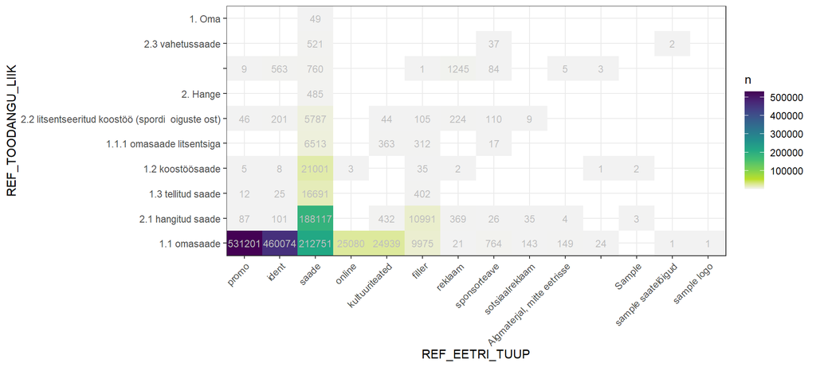

The “ident” category is explained in the accompaning documents, but it seems short (seconds to few minutes) clips containing titles such as “ETV2 Tiiter Kurg Laste”, “ID ETV2 punkar”, “ID Häirivad stseenid”, “TIITER hetke pärast Sügis Pehme”, “Kava HOMME (kevad)” - so mostly short intermittent messages.

## 3.3 Saade (tv show, n=452675) and its type categories over time

### 3.3.1 By number of tv shows (regardless of duration)

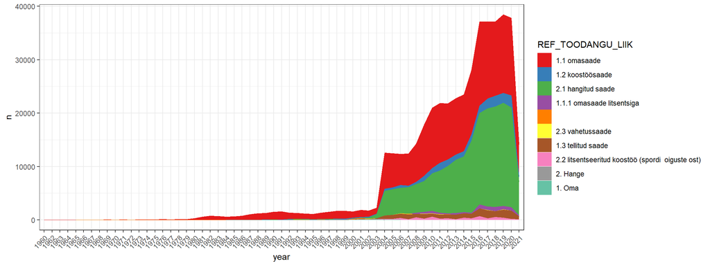

### 3.3.2 By actual hours on air

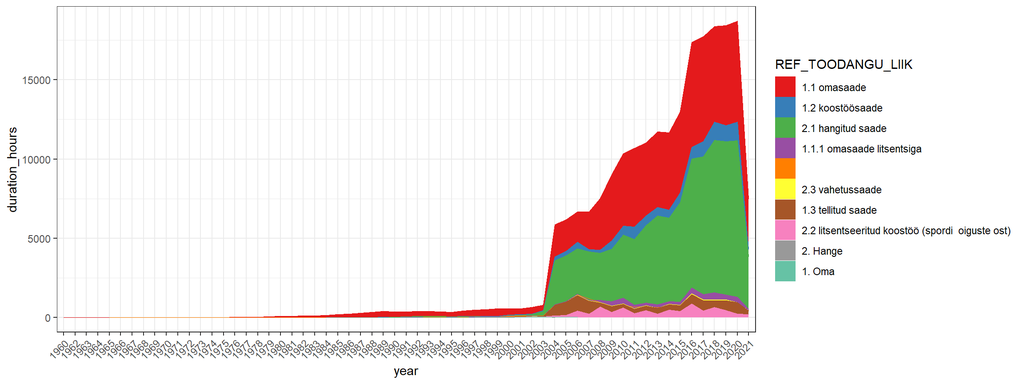

Issue: 13372 have no duration entry; mostly before 2000 Those which do are displayed above, to give an idea how much time is allocated to different show types.

The plot below gives an overview of median saade duration over the years (a few outliers at very high values are omitted from this plot). The red line displays the percentage of saade/show entires which have a valid non-empty duration field. Since ~2000 there’s fairly clear clusters of shows: most are ~25min, there’s a smaller cluster at ~10min, and a smaller one at ~50min. The first plot is build on all the data (i.e. for series, every episode counts separately).

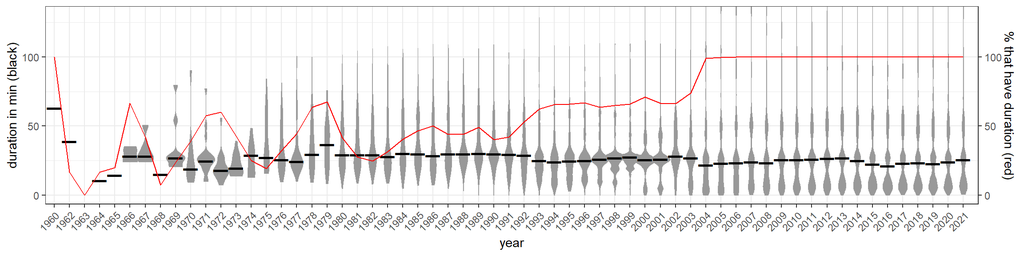

This zooms in on the last 20y, and series are are collapsed to one datapoint per year. The median is not necessarily informative, as there are 2-3 duration groups in there:

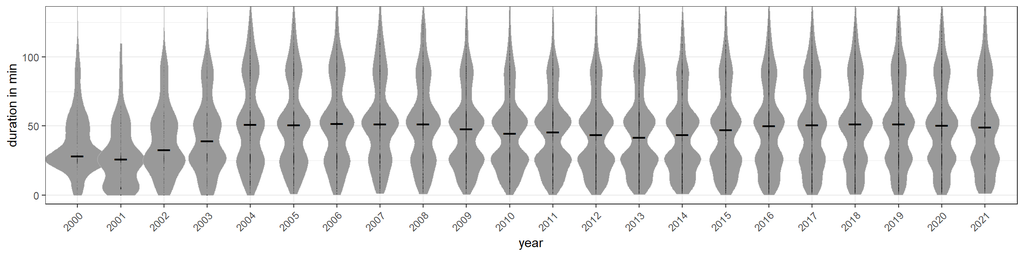

## 3.4 Durations of all REF_EETRI_TUUP categories

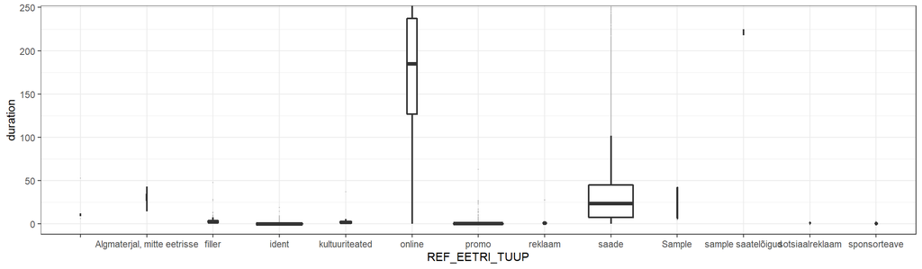

# 4 PROG (programme; n=300717)

EETRIAJAD seems like a smaller subset of the PROG table but with airing times: there’s 47985 PROG_IDs and 3307 SERIES_IDs which don’t occur in the EETRIAJAD table (but not vice versa). PROG only has “ESMAEETER” date (first airing, but 45986 missing values) and duration. Most entries with a first air date also have an entry in EETRIAJAD (which make sense). It does have more granular genre information and synopses (although for 67% synopsis/description fields are empty). Some rows are almost entirely empty (e.g. PROG_ID=10008133744: “Uudistaja 7” “saade” “2. hange” “05.05.2003”, and that’s it, doesn’t belong to any series, has no more info).

## 4.1 Values in the variables:

|  | n_unique_values | n_empty | median_nchar |
| --- | --- | --- | --- |
| INDEKS | 287902 | 12816 | 16 |
| PROG_ID | 300717 | 0 | 11 |
| SERIES_ID | 56484 | 25625 | 11 |
| PEALKIRI | 69719 | 123361 | 9 |
| ORIG_PEALKIRI | 43018 | 248006 | 19 |
| TOO_PEALKIRI | 4209 | 293985 | 14 |
| SARI_PEALKIRI | 38308 | 25625 | 17 |
| SARI_ORIG_PEALKIRI | 3102 | 190925 | 9 |
| OSA | 2433 | 26547 | 4 |
| LAHI_EETER | 9659 | 63537 | 10 |
| KESTUS | 52613 | 2799 | 11 |
| KESTUS_MS | 52614 | 2799 | 4 |
| REF_EETRI_TUUP | 18 | 62 | 5 |
| REF_ZANR | 293 | 99230 | 16 |
| REF_VALDKOND | 14 | 97717 | 15 |
| REF_TOODANGU_LIIK | 12 | 7165 | 12 |
| REF_SIHTRUHM | 9 | 106449 | 12 |
| REF_EESMARK | 8 | 102842 | 14 |
| REF_ALAMVALDKOND | 58 | 98441 | 21 |
| REF_KEEL | 544 | 81901 | 5 |
| REF_EETRISAGEDUS | 7 | 191901 | 12 |
| REF_SAATELIIK | 25 | 259966 | 10 |
| REF_SARJALISUS | 6 | 103136 | 4 |
| TOOTJAMAA | 828 | 126997 | 5 |
| TOOTANGU_AASTA | 113 | 82621 | 4 |
| PARIM_VERSIOON | 259641 | 41077 | 11 |
| PARIM_VERSIOON_STAATUS | 5 | 41077 | 11 |
| MARKUS | 26330 | 248402 | 30 |
| SUNOPSIS | 71182 | 206934 | 216 |
| KIRJELDUS | 11184 | 279065 | 536 |
| ESMAEETER | 13325 | 45986 | 10 |
| PIIRANG | 300 | 299789 | 61 |

|  | most_frequent |
| --- | --- |
| PROG_ID | “10006405134” (1), “10006408954” (1), “10006448046” (1), “10006751345” (1), “10006760800” (1), “10006760806” (1) |
| SERIES_ID | “10011108311” (1313), “10010643274” (792), “10011785117” (735), “10043308062” (580), “10011108331” (491), “10027622717” (484) |
| TOO_PEALKIRI | "" (293985), “AK 21.00 E-P” (365), “AK(vene keeles)” (365), “AK 18.00 E-P” (363), “17.00” (261), “AK 17.00 E-L” (255) |
| SARI_PEALKIRI | "" (25625), “Aktuaalne kaamera” (21871), “KULTUURITEATED” (10346), “Aktuaalne kaamera (vene keeles)” (8046), “Sport” (5100), “Aktuaalne kaamera (viipekeeles)” (4507) |
| SARI_ORIG_PEALKIRI | "" (190925), “20.00” (6071), “21.00” (5487), “17.00” (3493), “Vikerraadio” (3287), “21.00 AK+ILM” (2556) |
| OSA | " 1" (50006), " 2" (15284), " 8" (8661), " 3" (7883), " 9" (7498), " 4" (7420) |
| LAHI_EETER | "" (63537), “12.05.2021” (288), “14.03.2010” (171), “15.08.2020” (128), “13.05.2021” (127), “22.05.2021” (118) |
| REF_EETRI_TUUP | “saade” (196657), “promo” (74614), “kultuuriteated” (9495), “online” (8591), “filler” (4310), “ident” (3132) |
| REF_ZANR | "" (99230), “4.10 uudistebülletään” (77476), “1.9 seiklus” (15542), “4.1 ajakiri” (14877), “1.1 draama” (13264), “4.11 ülevaade, ringvaade” (9707) |
| REF_VALDKOND | "" (97717), “5. uudised” (74061), “1. lavastuslikud saated” (39592), “8. elusaated” (14533), “4. spordisaated” (14396), “6. informatiivsed saated” (13367) |
| REF_TOODANGU_LIIK | “1.1 omasaade” (226087), “2.1 hangitud saade” (48651), "" (7165), “2.2 litsentseeritud koostöö (spordi oiguste ost)” (5121), “1.2 koostöösaade” (4488), “1.1.1 omasaade litsentsiga” (4224) |
| REF_SIHTRUHM | “määratlemata” (119429), "" (106449), “pere” (29236), “lapsed kuni 14 a.” (21753), “keelevähemus” (14495), “muu sotsiaalne vähemus” (5636) |
| REF_EESMARK | "" (102842), “informeerimine” (98069), “meelelahutus” (45230), “elu- või kultuurikogemusega rikastamine” (20565), “harimine, kasvatus” (14429), “kaasamine sündmustesse ja aruteludesse, osalus” (11446) |
| REF_ALAMVALDKOND | "" (98441), “5.1 päevauudised, sh. ilmateade” (70405), “1.7 animatsioon” (14902), “1.1 TV sari” (9206), “1.2 TV seriaal” (8251), “4.3 spordiuudised” (7151) |
| REF_KEEL | “eesti” (141064), "" (81901), “vene” (37475), “inglise” (21899), “prantsuse” (3875), “tekstita” (1915) |
| REF_EETRISAGEDUS | "" (191901), “iga argipäev” (48766), “iga päev” (39158), “kord nädalas” (19839), “kord aastas” (474), “üle nädala” (332) |
| REF_SAATELIIK | "" (259966), “REGISTERED” (28358), “Lastesaade” (9585), “Dokk” (913), “Koncert” (460), “Teadusdokk” (214) |
| REF_SARJALISUS | “sari” (157990), "" (103136), “üksiksaade” (17063), “seriaal” (8344), “tsükkel” (7437), “lühisari” (6747) |
| TOOTJAMAA | “Eesti” (127120), "" (126997), “Suurbritannia” (11515), “Prantsusmaa” (7256), “Venemaa” (4703), “USA” (3466) |
| TOOTANGU_AASTA | “2000” (18532), “2016” (12241), “2018” (11330), “2017” (10852), “2015” (10452), “2008” (10154) |
| PARIM_VERSIOON_STAATUS | “Eetrikoopia” (144526), “Otse” (71801), “Vahekoopia” (41304), "" (41077), “Server” (2009) |
| PIIRANG | "" (299789), “Kasutuspiirang! Teistes saadetes ei tohi kasutada katkendeid.” (300), “materjali kasutamisel tuleb saate autorile Marica Lillemetsale maksta autoritasu” (61), “BBC multifilmidel põhinev … |

SUNOPSIS and KIRJELDUS have short texts (median 200 and 500 characters). The longest kirjeldus is 35260 chars, the longest synopsis is 4000. Example synopis: *“Estonia” Teatri laevareisi kolmas peatuskoht oli Oslo, kus esineti galakontserdiga. Viimases saates tehakse kokkuvõtteid ooperireisist, kuulete estoonlaste muljeid ja arvamusi. Saatejuht Ruth Alaküla".* Some kirjeldus entries in English. Some have the same text in both fields (but noticed kirjeldus can have broken letters), some have only one field, 17243 have both, *202525 have neither*. Example: SUNOPSIS=meelelahutuslik-õpetuslik lastesaade, KIRJELDUS= *Koos Milo, Bella, Fizzi ja Jake’iga on vahva laule laulda ning maailma avastada, Maxil või Judyl on aga varuks mõni jutt ja meisterdamise idee. Tõlkis Anti Reinthal.*

## 4.2 Categories in REF_ZANR

There’s over a hundred categories with only a 1 or a few entries. The most frequent category is "" i.e. empty.

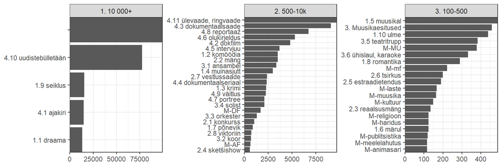

Less frequent categories (<100), in descending order:

```
## 1. Lavastuslikud žanrid, M-dok., M-venekeelsed saated, M-dok.sari, 4. Tõsielulised žanrid, M-animafilm, M-teater, 1.11 vestern, 1.12  õudus, M-sari, M-eestidok, M-olukirjeldus, M-hanke, M-  meelelahutus, M-   süvamuusika, M-  muusika, M-Kultuurisaated, M-   kultuur, M-elusaated, M-noortesari, M-s…
```

## 4.3 Categories in REF_VALDKOND

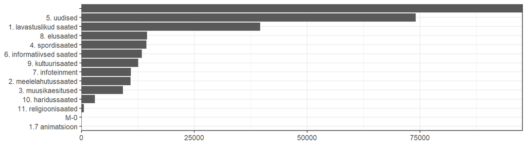

## 4.4 Categories in REF_ALAMVALDKOND (subcategories of REF_VALDKOND)

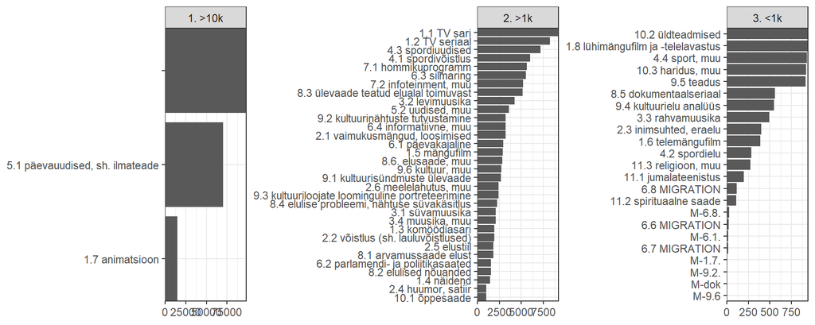

## 4.5 Category degree

If one were to construe PROG_IDs and REF_ZANR as a directed network, that would be the in-degree distribution:

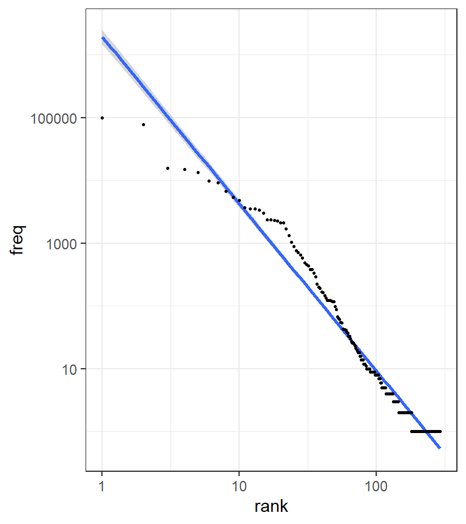

(each dot is a genre; I added a linear regression fit but that’s probably not the most optimal solution to model power laws)

# 5 ALLIKAD (sources; n=412120)

This seems to be mostly technical details on the recordings of the tv material.

## 5.1 Values in the variables:

|  | n_unique_values | n_empty |
| --- | --- | --- |
| INDEKS | 269147 | 7663 |
| PROG_ID | 274786 | 0 |
| RECORD_ID | 412120 | 0 |
| VERSION_ID | 334562 | 74838 |
| HOUSEID | 251313 | 158577 |
| MARKUS | 44299 | 358321 |
| TUUP | 6 | 0 |
| SIGNATUUR | 56625 | 317198 |
| ALGUS | 5987 | 145474 |
| LOPP | 77097 | 145551 |
| KESTUS | 62124 | 90348 |
| KESTUS_MS | 62125 | 90348 |
| ALLIKA_STAATUS | 21 | 0 |
| LOODUD | 5726 | 8113 |
| HELI_12 | 787 | 262445 |
| HELI_34 | 446 | 393989 |
| SUBTIITRID | 28370 | 380397 |
| KORVETATUD_SUBTIITRID | 66 | 411584 |
| SERVER | 9 | 185473 |
| ENCODING_RF | 13 | 220684 |
| AUDIOMOD | 7 | 164647 |
| HELI_1 | 8 | 255185 |
| HELI_2 | 8 | 268335 |
| HELI_3 | 7 | 406882 |
| HELI_4 | 6 | 407042 |
| VARVISYSTEEM | 4 | 94381 |
| VARV | 4 | 95224 |
| PILDISUHE | 3 | 86396 |
| AUDIOKVALITEET | 6 | 282940 |
| VIDEOKVALITEET | 7 | 129446 |
| AUDIOQUALNOTE | 4 | 411975 |
| DUBLEERIMINE | 9 | 401755 |
| KEEL | 52 | 403125 |

# 6 SISUKIRJELDUS (content descriptions; n=212710)

- No SERIES_ID columns
- but PROG_ID duplicates unlike in the others; seems to describe multiple parts of the same show, but sometimes there’s start time but no end time entry, and the start time entry can be 10 hours, e.g. “11:35:51:00”.
- There are 293049 PROG_IDs and 280547 INDEKS’s in PROG which do not occur in SISUKIRJELDUS, but all IDs in SISUKIRJELDUS are represented in PROG (and almost all, except for 431, occur in EETRIAJAD).
- But it’s not only old ones missing, e.g. the earliest show with a SISUKIRJELDUS has an EETRIAEG air time entry of “1965-07-12”. The missing ones are not immediately obvious (both oma and hange types, both Estonian and foreign, various genres, lengths, EETRI_TUUP types).

## 6.1 Values in the variables

|  | n_unique_values | n_empty | median_nchar |
| --- | --- | --- | --- |
| INDEKS | 7355 | 5564 | 16 |
| PROG_ID | 7668 | 0 | 11 |
| RECORD_ID | 8178 | 0 | 11 |
| TECHINFO_ID | 212710 | 0 | 11 |
| HOUSEID | 7570 | 9722 | 21 |
| ALGUS | 20388 | 1279 | 11 |
| LOPP | 7705 | 201470 | 11 |
| ALGUS_MS | 20394 | 1279 | 5 |
| LOPP_MS | 7706 | 201470 | 6 |
| PEALKIRI | 2498 | 208154 | 12 |
| SISUKIRJELDUS | 171414 | 193 | 40 |

|  | most_frequent |
| --- | --- |
| INDEKS | "" (5564), “2001-084205-0019” (413), “2003-084205-0023” (410), “2004-000199-0009” (404), “2002-084205-0022” (399), “2001-083517-0001” (331) |
| PROG_ID | “10023006996” (413), “10009760453” (410), “10009784881” (404), “10009739479” (399), “10009716357” (331), “10021745304” (284) |
| RECORD_ID | “10023007002” (413), “10009760458” (410), “10009784886” (404), “10009739484” (399), “10009720452” (227), “10009772305” (220) |
| TECHINFO_ID | “10023226323” (1), “10023226325” (1), “10023226327” (1), “10023226329” (1), “10023226331” (1), “10023226333” (1) |
| HOUSEID | "" (9722), “2001-084205-0019_0001” (413), “2003-084205-0023_0001” (410), “2004-000199-0009_0001” (404), “2002-084205-0022_0001” (399), “2000-081302-0001_0002” (227) |
| PEALKIRI | "" (208154), “Vahekõll” (115), “NEW_MIGR:27.04.2006” (57), “vahekõll” (51), “Helilindilt” (46), “Saatepea” (35) |

The median descriptions are 40 characters long. Don’t seem to overlap with SUNOPSIS in PROG but might.

## 6.2 —

# 7 Topic modelling, combining all the text fields available

- Concatenating here all the (non-technical) keyword fields (genre, audience, etc) and content fields (synopsis fields from PROG and content descriptions from SISUKIRJELDUS) + lemmatizing the longer/non-keyword text fields (keywords are kept as they are and prefixed with “REF_”).
- Since the concatenation can potentially produce very uneven document lengths/number of terms per entry, I log-transformed all the frequencies of the terms coming from the free-text fields (keywords occur once per entry by definition even after concatenating series). Still, a long description can give more weight to the description terms than the metadata keywords. This would need further work.
- Stopwords (conjunctions, numbers, adverbs etc) are removed.
- This is based on the entire corpus, to get the most data to inform the topic model, but the analysis over time will be only on the “saade” category, as others are very small and/or seem to follow different logic (particularly “online”).
- Topic model is LDA with k=9, alpha=0.05, beta = 0.01. Using low number of topics here to facilitate diachronic comparison.
- One way or another it’s pretty much a sparse short-text modelling task, as some entries have very little descriptive content/metadata. To amend that a bit, I concatenated series (entries with a non-empty SERIES_ID field) into single entries (preserving/concatenating all their descriptions; but only one non-empty keyword in the keyword fields). This also solves some of the gaps in the data (some serie parts may have keywords or content, others not; making sure here to summarize using non-empty fields).
- This leaves 17k entries of “saade” that have aired since 2000.
- Another issue is mixed languages, some descriptive fields have English in them, which messes with the lemmatization and downstream topic distributions (I included English stopword removal to reduce their effect a bit).

## 7.1 Exploring topics

The topic model viewed through the lens of top 10 topic words; each row is a topic. Keep in mind that in LDA each document is a mixture of all the topics (but these values can also be 0). E.g. “Aktuaalne Kaamera” is mostly a mixture of topic 3 (42%) and 6 (55%). Note that this topic model might not be optimal, as the parameterization is fairly arbitrary (could also be better with phrases concatenated, e.g. right now “aktuaalne kaamera” is treated as two words). But this approach is a way to get around the issue of the sporadic lack of metadata and descriptions - some fields are populated for some entries, some for others, the topic model attempts to find latent structure underneath.

| topic | topic_keywords | summary |
| --- | --- | --- |
| 1 | saatejuht inimene küsimus milline režissöör produtsent riik erinev eesti tootja | mostly metadata, production |
| 2 | REF_1._lavastuslikud_saated REF_1.5_mängufilm REF_meelelahutus REF_1.1_draama kultuuriteated REF_1.4_näidend REF_1.2_komöödia REF_määratlemata REF_lapsed_kuni_14_a. REF_1.7_animatsioon | entertainment, animation, culture |
| 3 | REF_3._muusikaesitused REF_3.1_süvamuusika aktuaalne REF_3.2_levimuusika kaamera REF_3.1_ansambel REF_kunstielamuse_pakkumine REF_3.4_solist REF_3.3_orkester REF_3.4_muusika,_muu | music related; also news |
| 4 | sõber otsustama sattuma tahtma suu leidma otsima minema puhas avastama | descriptive contents/synopses, fairly generic/more drama(?) |
| 5 | saama raske tegema laps tomi elu perekond lasteekraan leidma sundima | same, but more about kids/family(?) |
| 6 | eesti laul lava dirigent aplaus kirik REF_9._kultuurisaated tallinn laulja kell | Estonia, Tallinn, music/concents/culture |
| 7 | REF_4.2_dokfilm REF_6._informatiivsed_saated REF_informeerimine REF_6.4_informatiivne,_muu REF_määratlemata REF_elu-_või_kultuurikogemusega_rikastamine REF_8._elusaated jalgpall REF_6.3_silmaring REF_… | documentary, information, but also sport |
| 8 | tekst foto lõputiiter koostama saatepea jüri rääkima tiiter istuma rein | looks like technical metadata but descriptive |
| 9 | ama one hima life hama first two lov find lik | English, garbled by the Estonian lemmatizer |

This UMAP dimension reduction shows all the saade type entries, mapped by their topic composition; each dot is a one-off show or a film or a series, colored by its primary topic (areas of multiple colors hence indicate entries with mixed topics, monochrome areas are likely single-topic entries).

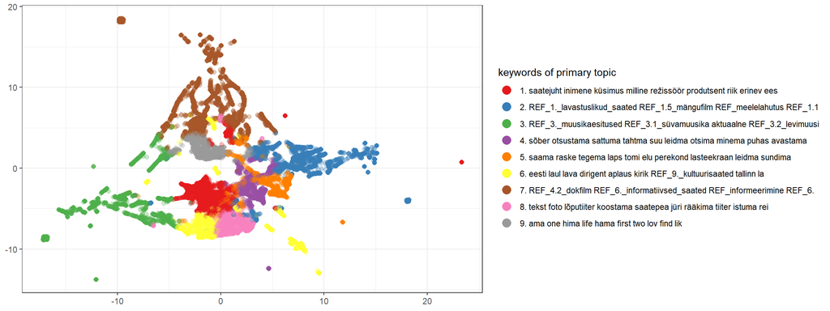

## 7.2 Topics over time

This sums the hours on air durations for each topic for each month 2000 onwards. Since each entry/document is a normalized distribution over all topics, getting minutes per topic is a simple matter of multiplying the distributions by the minutes on air (as recorded in EETRIAJAD) and summing those for each unit of time (here monhts). The plot below normalizes the “topic minutes” for each month to maintain comparability. But:

- note that this only takes into account tv contents only in the “saade” category, which doesn’t cover everything (for example sport seems like a separate thing; online seems different),
- only those that actually have some descriptions (keywords or synopses; 159 of saade don’t),
- and have time/duration entries in EETRIAJAD (2461 of saade 2000 onwards don’t).
- Also excluding 26 entries where the duration is over 6h assuming it’s errors (don’t know what’s a reasonable limit though, maybe some shows *are* super long).
- And again, bear in mind, it’s a first messy possibly non-optimal attempt.

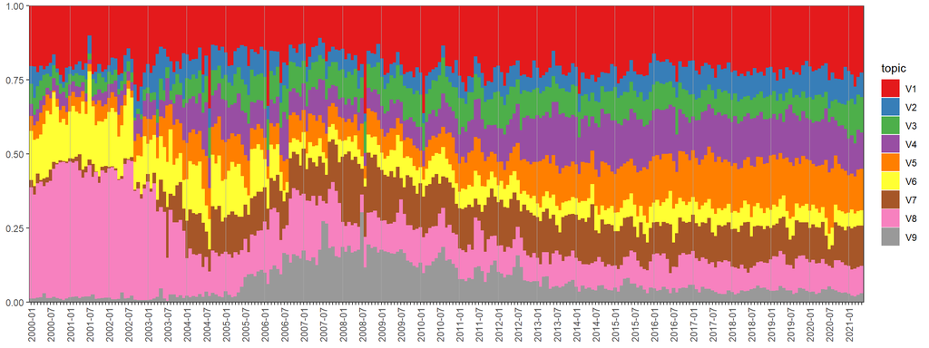

The gray topic is English desctiptions, which seems to have been more of an issue in mid-2000s. Red is the big stable topic, containing hints at politics, analytics, but also some sports. The pink one that ballooned and then diminishes seems to be a metadata thing in description fields - the longer keyword list with a higher-specificity lambda parameter is *lõputiiter foto koostama tekst saatepea istuma laud katkend kaadritagune raivo panoraam lembit jaanus lõputiitrid kaader algustiiter sulev väli aare ain sirje enn merle peep erki*, so a lot of names and techninal sounding terms. May be a topic, may be an issue of fields that should be in participant fields having been entered in content description or synopsis fields; would require further insight. The increase of the orange topic seems to be an increase of family oriented content like “lasteekraan”, “prillitoos”, “leiutaja” (Lotte?), but also Downton Abbey. The brown one is a bit of a mess of sports, Hercule Poirot and documentaries (so the *k* is apparently suboptimal), therefore a bit hard to interpret without diving into the descriptions.

## 7.3 —

Sidenote: noticed something odd: the distribution of the number of entries *per* month looks pretty unnatural (the low end is mostly early 2000s, but don’t know why there’s this multi-multimodal distribution).

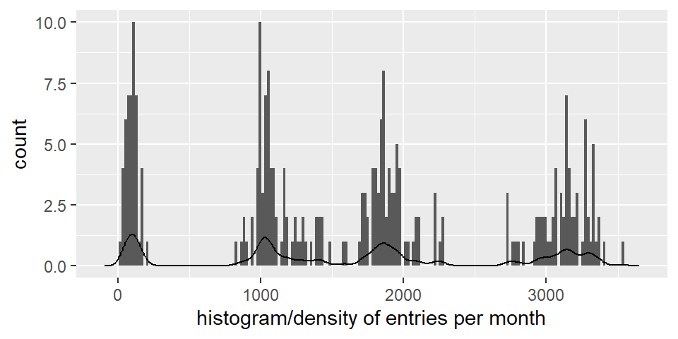